# Becas

Jesus Rincon

11 de marzo de 2016

# Hogares

Tomamos en cuenta que buscamos una habitacion donde los factos que se consideran mas importantes son, el tiempo de traslado hacia la universidad y el piso del edificio en donde sera el posible hospedaje.

Iniciamos el proceso de cargar las librerias a emplear, y cargar el documento respectivo

# Preprocesamiento de los datos

## Eliminamos las columnas consideradas innecesarias.

Tales como: *Foto* Distrito *Habitaciones Disponibles* Precio Mensual

## Cambiamos los datos del Tipo de habitacion hacia una vista minable

```r
df$Tipo.de.Inmueble <- as.character(df$Tipo.de.Inmueble)
df$Tipo.de.Inmueble[df$Tipo.de.Inmueble == "Appartamento"] <- 2
df$Tipo.de.Inmueble[df$Tipo.de.Inmueble == "Appartameno"] <- 2
df$Tipo.de.Inmueble[df$Tipo.de.Inmueble == "Appartamenti"] <- 2
df$Tipo.de.Inmueble[df$Tipo.de.Inmueble == "Apartamento"] <- 2
df$Tipo.de.Inmueble[df$Tipo.de.Inmueble == "Apparrtamento"] <- 2
df$Tipo.de.Inmueble[df$Tipo.de.Inmueble == "Mini Appartamento"] <- 0
df$Tipo.de.Inmueble[df$Tipo.de.Inmueble == "Mini appartamento"] <- 0
df$Tipo.de.Inmueble[df$Tipo.de.Inmueble == "Mini\nAppartamento"] <- 0
df$Tipo.de.Inmueble[df$Tipo.de.Inmueble == "Monolocale"] <- 1
```

## Cambiamos los datos en Tipo de Piso

Como se habia acordado en clase, las definiciones T, R, S, y ST son irrelevantes, por lo que le daremos la ponderacion de un primer piso a estas.

```r
df$Piso <- as.character(df$Piso)
df$Piso[df$Piso == "T"] <- 1
df$Piso[df$Piso == "R"] <- 1
df$Piso[df$Piso == "S"] <- 1
df$Piso[df$Piso == "ST"] <- 1
df$Piso <- gsub("°","",df$Piso)
```

## Cambiamos ahora la direccion por el tiempo en segundos

Aqui, nos conectamos al API de google maps para saber con determinacion cuanto tiempo tardaremos desde la habitacion hasta la universidad.

```r
df$Dirección <- gsub("\n"," ",df$Dirección)
api_key = "AIzaSyBG65bqbSYkHBe25jbQ08jHZMzOtfa4fys"
origen = "Università di Roma - Sapienza"
for( i in 1:nrow((df))){
  # Colocar su API Key
  destino = as.character(df$Dirección[i])
  api_url = get_url(origen, destino, api_key)
  datos = get_data(api_url)
  datos$rows$elements[[1]]$status
  if(datos$rows$elements[[1]]$status == "ZERO_RESULTS" || datos$rows$elements[[1]]$status == "NOT_FOUND"){
    tiempo = 100
  } else {
    tiempo = parse_data(datos)

  }
  df$Dirección[i]= tiempo

}
```

## Cambiamos la descripcion de la habitacion

Ahora bien, para llegar a este punto se usa un sistema de aparicion de palabras, para poder ponderar la calidad o comodidad que tiene una habitacion segun su descripcion, EL saber si tiene cocina, baño, terraza, sala de estar, corredor, aire acondicionado, internet, entrada independiente, para asi saber cual es la habitacion mas destacada.

```r
df$Descripción <- as.character(df$Descripción)
df$Descripción <- gsub("2 bagno,","11",df$Descripción)
df$Descripción <- gsub("2 bagni","11",df$Descripción)
df$Descripción <- gsub("2 bagni.","11",df$Descripción)
df$Descripción <- gsub("2bagni","11",df$Descripción)
df$Descripción <- gsub("3 bagni","111",df$Descripción)
df$Descripción <- gsub("Ingresso,","1",df$Descripción)
df$Descripción <- gsub("Ingresso con","1",df$Descripción)
df$Descripción <- gsub("ingresso con","1",df$Descripción)
df$Descripción <- gsub("ingresso,","1",df$Descripción)
df$Descripción <- gsub("ingresso,","1",df$Descripción)
df$Descripción <- gsub("Ingresso/corridoio,","11",df$Descripción)
df$Descripción <- gsub("Ingresso/salone","11",df$Descripción)
df$Descripción <- gsub("Ingresso/soggiorno,","11",df$Descripción)
df$Descripción <- gsub("Ingresso/living,","11",df$Descripción)
df$Descripción <- gsub("cucna,","1",df$Descripción)
df$Descripción <- gsub("cucina,","1",df$Descripción)
df$Descripción <- gsub("cucina abitabile,","1",df$Descripción)
df$Descripción <- gsub("cucina abitbile,","1",df$Descripción)
df$Descripción <- gsub("soggiorno,","1",df$Descripción)
df$Descripción <- gsub("corridoio,","1",df$Descripción)
df$Descripción <- gsub("ingresso cucina/living,","11",df$Descripción)
df$Descripción <- gsub("cucina/living,","11",df$Descripción)
df$Descripción <- gsub("terrazzo","1111",df$Descripción)
df$Descripción <- gsub("balcone","111",df$Descripción)
df$Descripción <- gsub("balconcino","111",df$Descripción)
df$Descripción <- gsub("internet","11111",df$Descripción)
df$Descripción <- gsub("4 camere,","111",df$Descripción)
df$Descripción <- gsub("camera matrimoniale,","111",df$Descripción)
df$Descripción <- gsub("3 camere,","11",df$Descripción)
df$Descripción <- gsub("2 camere,","1",df$Descripción)
df$Descripción <- gsub("1 camere,","1",df$Descripción)
df$Descripción <- gsub("camere,","",df$Descripción)
df$Descripción <- gsub("camere","",df$Descripción)
df$Descripción <- gsub("camer,","",df$Descripción)
df$Descripción <- gsub("camera,","",df$Descripción)
df$Descripción <- gsub("salone,","1",df$Descripción)
df$Descripción <- gsub("salone/living,","1",df$Descripción)
df$Descripción <- gsub("salottino,","1",df$Descripción)
df$Descripción <- gsub("salone","1",df$Descripción)
df$Descripción <- gsub("sala da pranzo,","1",df$Descripción)
df$Descripción <- gsub("living","1",df$Descripción)
df$Descripción <- gsub("cucina","1",df$Descripción)
df$Descripción <- gsub("ripostiglio,","1",df$Descripción)
df$Descripción <- gsub("bagno di servizio,","1",df$Descripción)
df$Descripción <- gsub("bagno,","1",df$Descripción)
df$Descripción <- gsub("bagno","1",df$Descripción)
df$Descripción <- gsub("bagni","1",df$Descripción)
df$Descripción <- gsub("doppio","1",df$Descripción)
df$Descripción <- gsub("doppio,","1",df$Descripción)
df$Descripción <- gsub("angolo cottura,","1",df$Descripción)
df$Descripción <- gsub("camera e","1",df$Descripción)
df$Descripción <- gsub("aria condizionata,","111",df$Descripción)
df$Descripción <- gsub("disimpegno,","1",df$Descripción)
df$Descripción <- gsub("Ingresso","1",df$Descripción)
df$Descripción <- gsub("ristrutturato","1",df$Descripción)
df$Descripción <- gsub("di servizio","",df$Descripción)
df$Descripción <- gsub("termo autonomo","11",df$Descripción)
df$Descripción <- gsub("ripostiglio","1",df$Descripción)
df$Descripción <- gsub("salotto,","1",df$Descripción)
df$Descripción <- gsub("piccolo","1",df$Descripción)
df$Descripción <- gsub("stanze","1",df$Descripción)
df$Descripción <- gsub("ampiio","1",df$Descripción)
df$Descripción <- gsub("con","",df$Descripción)
df$Descripción <- gsub("2,","11",df$Descripción)
df$Descripción <- gsub("1,","1",df$Descripción)
df$Descripción <- gsub("3,","111",df$Descripción)
df$Descripción <- gsub("1.","1",df$Descripción)
df$Descripción <- gsub("2.","11",df$Descripción)
df$Descripción <- gsub("3 ","111",df$Descripción)
df$Descripción <- gsub(" 3","111",df$Descripción)
df$Descripción <- gsub("1 ","1",df$Descripción)
df$Descripción <- gsub(" 2","11",df$Descripción)
df$Descripción <- gsub("tre","",df$Descripción)
df$Descripción <- gsub("e","",df$Descripción)
df$Descripción[38] = "1111111"
df$Descripción[62] = "111111"
df$Descripción[103] = "1111"
df$Descripción[nchar(df$Descripción) <= 5] <- nchar(df$Descripción)
df$Descripción[nchar(df$Descripción) >= 4] <- nchar(df$Descripción)
```

## Residente apropiado para la habitacion

En este punto seleccionamos la disponibilidad para hombre o mujer en una habitacion.

```r
df$Notas <-  sub(".*ragazzi/ragazze.*","1",df$Notas)
df$Notas <-  sub(".*ragazze/ragazzi.*","1",df$Notas)
df$Notas <-  sub(".*ragazze/i.*","1",df$Notas)
df$Notas <-  sub(".*ragazzi/e.*","1",df$Notas)
df$Notas <-  sub(".*ragazzi.*","2",df$Notas)
df$Notas <-  sub(".*ragazze.*","3",df$Notas)
df$Notas[39] <- 1
```

## Ahora bien, ploteamos

Mostramos una grafica en donde los ejes son la descripcion y el piso en donde se encuentra

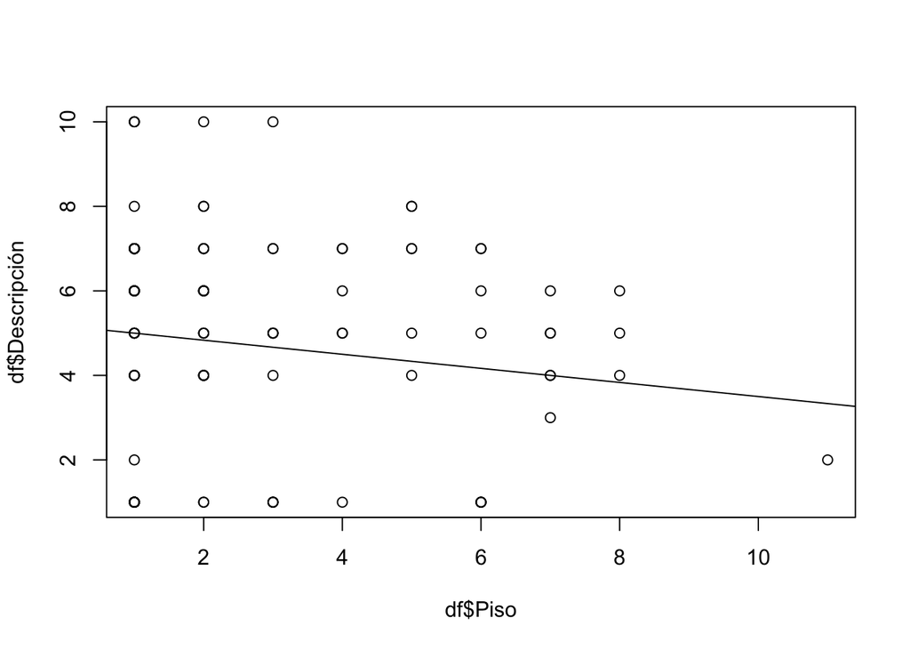